# **Introduction to Python Project : FoodHub Data Analysis**

### Problem Statement

FoodHub is an online food delivery app that connects customers with multiple restaurants. They want to analyze customer order data to understand restaurant demand and improve service. As a Data Scientist, your job is to explore the data and provide useful insights to help the business grow.

### Data Dictionary

order_id: Unique ID

customer_id: ID of the customer

restaurant_name: Name of the restaurant

cuisine_type: Type of cuisine ordered

cost_of_the_order: Total cost

day_of_the_week: Day when the order was placed

rating: Rating (out of 5) given by the customer

food_preparation_time: Time (in minutes)

delivery_time: Time (in minutes)

### Let us start by importing the required libraries

```python
# Import libraries
import pandas as pd
import numpy as np
import matplotlib.pyplot as plt
import seaborn as sns
```

```python
# Load the data
df = pd.read_csv('/content/drive/MyDrive/Week1_project/foodhub_order.csv')
```

```python
# View the first 5 rows of the dataset
df.head()
```

|  | order_id | customer_id | restaurant_name | cuisine_type | cost_of_the_order | day_of_the_week | rating | food_preparation_time | delivery_time |
| --- | --- | --- | --- | --- | --- | --- | --- | --- | --- |
| 0 | 1477147 | 337525 | Hangawi | Korean | 30.75 | Weekend | Not given | 25 | 20 |
| 1 | 1477685 | 358141 | Blue Ribbon Sushi Izakaya | Japanese | 12.08 | Weekend | Not given | 25 | 23 |
| 2 | 1477070 | 66393 | Cafe Habana | Mexican | 12.23 | Weekday | 5 | 23 | 28 |
| 3 | 1477334 | 106968 | Blue Ribbon Fried Chicken | American | 29.20 | Weekend | 3 | 25 | 15 |
| 4 | 1478249 | 76942 | Dirty Bird to Go | American | 11.59 | Weekday | 4 | 25 | 24 |

### **Question 1:** How many rows and columns are present in the data?

```python
print("Rows:", df.shape[0])
print("Columns:", df.shape[1])
```

```
Rows: 1898
Columns: 9
```

Question 2: What are the datatypes of the different columns in the dataset? (The info() function can be used)

```python
df.info()
```

```
<class 'pandas.core.frame.DataFrame'>
RangeIndex: 1898 entries, 0 to 1897
Data columns (total 9 columns):
 #   Column                 Non-Null Count  Dtype
---  ------                 --------------  -----
 0   order_id               1898 non-null   int64
 1   customer_id            1898 non-null   int64
 2   restaurant_name        1898 non-null   object
 3   cuisine_type           1898 non-null   object
 4   cost_of_the_order      1898 non-null   float64
 5   day_of_the_week        1898 non-null   object
 6   rating                 1898 non-null   object
 7   food_preparation_time  1898 non-null   int64
 8   delivery_time          1898 non-null   int64
dtypes: float64(1), int64(4), object(4)
memory usage: 133.6+ KB
```

Question 3: Are there any missing values in the data? If yes, treat them using an appropriate method.

```python
# Convert 'Not given' to NaN (missing values)
df['rating'] = pd.to_numeric(df['rating'], errors='coerce')

# Check for missing values in the 'rating' column
df.isnull().sum()

# Fill missing values in the 'rating' column with the mean
df['rating'].fillna(df['rating'].mean())
```

|  | rating |
| --- | --- |
| 0 | 4.344234 |
| 1 | 4.344234 |
| 2 | 5.000000 |
| 3 | 3.000000 |
| 4 | 4.000000 |
| ... | ... |
| 1893 | 5.000000 |
| 1894 | 5.000000 |
| 1895 | 4.344234 |
| 1896 | 5.000000 |
| 1897 | 4.344234 |

1898 rows × 1 columns

**dtype:** float64

```python
df.info()
```

```
<class 'pandas.core.frame.DataFrame'>
RangeIndex: 1898 entries, 0 to 1897
Data columns (total 9 columns):
 #   Column                 Non-Null Count  Dtype
---  ------                 --------------  -----
 0   order_id               1898 non-null   int64
 1   customer_id            1898 non-null   int64
 2   restaurant_name        1898 non-null   object
 3   cuisine_type           1898 non-null   object
 4   cost_of_the_order      1898 non-null   float64
 5   day_of_the_week        1898 non-null   object
 6   rating                 1162 non-null   float64
 7   food_preparation_time  1898 non-null   int64
 8   delivery_time          1898 non-null   int64
dtypes: float64(2), int64(4), object(3)
memory usage: 133.6+ KB
```

Question 4: Check the statistical summary of the data. What is the minimum, average, and maximum time it takes for food to be prepared once an order is placed?

```python
df.describe()

print("Min preparation time:", df['food_preparation_time'].min(), "minutes")
print("Average preparation time:", df['food_preparation_time'].mean(), "minutes")
print("Max preparation time:", df['food_preparation_time'].max(), "minutes")
```

```
Min preparation time: 20 minutes
Average preparation time: 27.371970495258168 minutes
Max preparation time: 35 minutes
```

Question 5: How many orders are not rated?

```python
unrated_orders = df['rating'].isnull().sum()
print("Orders not rated:", unrated_orders)
```

```
Orders not rated: 736
```

# Exploratory Data Analysis (EDA)

Question 6: Explore all the variables and provide observations on their distributions. (Generally, histograms, boxplots, countplots, etc. are used for univariate exploration.)

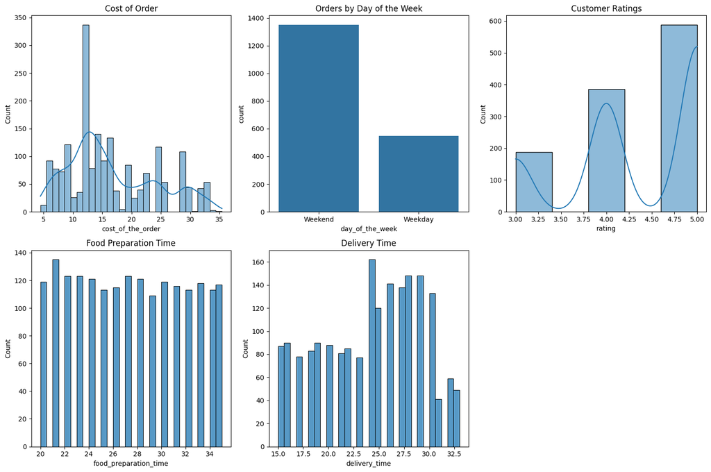

```python
# Plot distributions
plt.figure(figsize=(15, 10))

plt.subplot(2, 3, 1)
sns.histplot(df['cost_of_the_order'], bins=30, kde=True)
plt.title('Cost of Order')

plt.subplot(2, 3, 2)
sns.countplot(data=df, x='day_of_the_week')
plt.title('Orders by Day of the Week')

plt.subplot(2, 3, 3)
sns.histplot(df['rating'], bins=5, kde=True)
plt.title('Customer Ratings')

plt.subplot(2, 3, 4)
sns.histplot(df['food_preparation_time'], bins=30)
plt.title('Food Preparation Time')

plt.subplot(2, 3, 5)
sns.histplot(df['delivery_time'], bins=30)
plt.title('Delivery Time')

plt.tight_layout()
plt.show()
```

Question 7: Which are the top 5 restaurants in terms of the number of orders received?

```python
top_5_restaurants = df['restaurant_name'].value_counts().head(5)
print("Top 5 Restaurants:\n", top_5_restaurants)
```

```
Top 5 Restaurants:
 restaurant_name
Shake Shack                  219
The Meatball Shop            132
Blue Ribbon Sushi            119
Blue Ribbon Fried Chicken     96
Parm                          68
Name: count, dtype: int64
```

```python
weekend_data = df[df['day_of_the_week'].isin(['Saturday', 'Sunday'])]
print(weekend_data.shape)
```

```
(0, 9)
```

Question 9: What percentage of the orders cost more than 20 dollars?

```python
high_cost_orders = df[df['cost_of_the_order'] > 20]
percentage_high_cost = (len(high_cost_orders) / len(df)) * 100
print(f"{percentage_high_cost:.2f}% of orders cost more than $20.")
```

```
29.24% of orders cost more than $20.
```

Question 10: What is the mean order delivery time?

```python
mean_delivery_time = df['delivery_time'].mean()
print("Mean delivery time:", round(mean_delivery_time, 2), "minutes")
```

```
Mean delivery time: 24.16 minutes
```

Question 11: The company has decided to give 20% discount vouchers to the top 3 most frequent customers. Find the IDs of these customers and the number of orders they placed.

```python
top_customers = df['customer_id'].value_counts().head(3)
print("Top 3 Customers:\n", top_customers)
```

```
Top 3 Customers:
 customer_id
52832    13
47440    10
83287     9
Name: count, dtype: int64
```

Question 12: Perform a multivariate analysis to explore relationships between the important variables in the dataset. (It is a good idea to explore relations between numerical variables as well as relations between numerical and categorical variables)

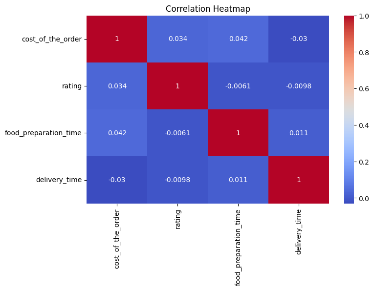

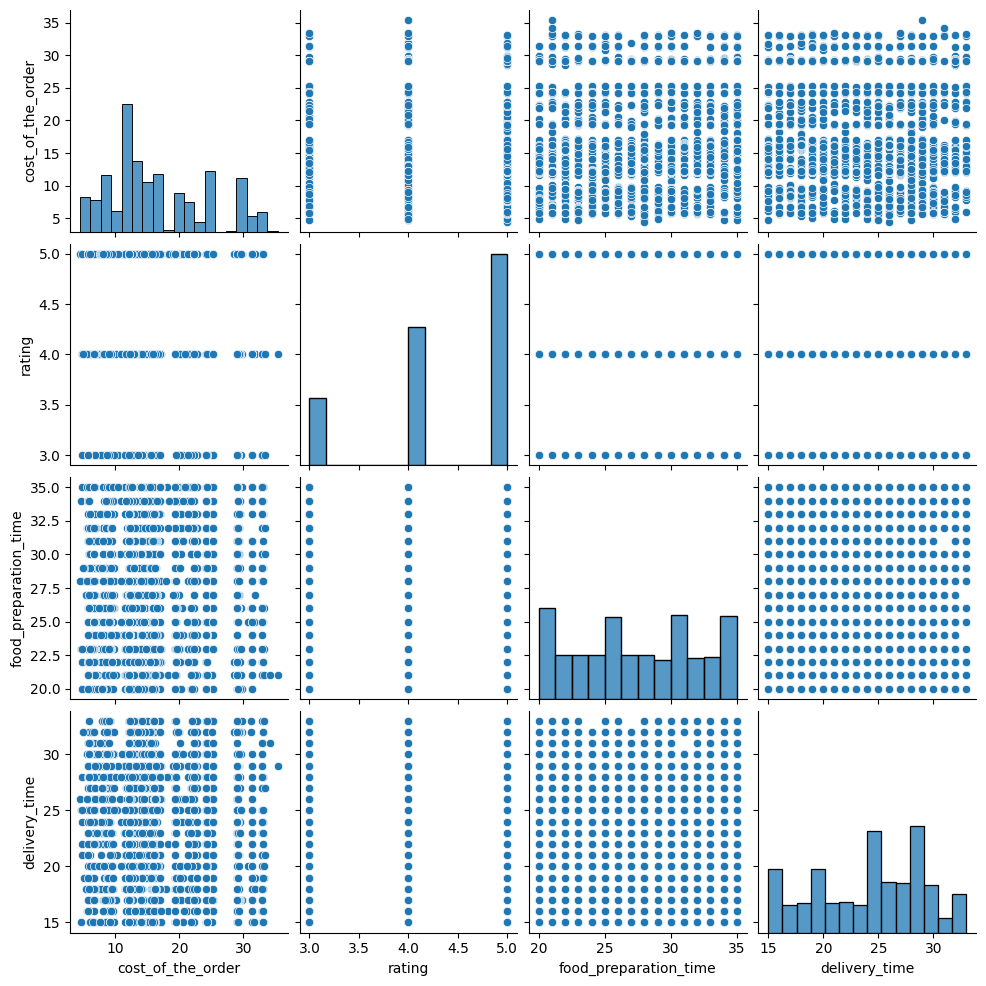

```python
# Correlation heatmap
plt.figure(figsize=(8, 5))
sns.heatmap(df[['cost_of_the_order', 'rating', 'food_preparation_time', 'delivery_time']].corr(), annot=True, cmap='coolwarm')
plt.title("Correlation Heatmap")
plt.show()

# Pairplot
sns.pairplot(df[['cost_of_the_order', 'rating', 'food_preparation_time', 'delivery_time']])
plt.show()
```

```python
df['rating'].value_counts()
```

| rating | count |
| --- | --- |
| 5.0 | 588 |
| 4.0 | 386 |
| 3.0 | 188 |

**dtype:** int64

```python
# Assuming 15% commission margin
margin = 0.15
df['revenue'] = df['cost_of_the_order'] * margin
total_revenue = df['revenue'].sum()
print("Total revenue generated: $", round(total_revenue, 2))
```

```
Total revenue generated: $ 4697.22
```

Question 15: The company wants to analyze the total time required to deliver the food. What percentage of orders take more than 60 minutes to get delivered from the time the order is placed? (The food has to be prepared and then delivered.)

```python
df['total_time'] = df['food_preparation_time'] + df['delivery_time']
long_orders_pct = (df[df['total_time'] > 60].shape[0] / df.shape[0]) * 100
print(f"{long_orders_pct:.2f}% of orders take more than 60 minutes.")
```

```
10.54% of orders take more than 60 minutes.
```

```python
weekday_delivery = df[~df['day_of_the_week'].isin(['Saturday', 'Sunday'])]['delivery_time'].mean()
weekend_delivery = df[df['day_of_the_week'].isin(['Saturday', 'Sunday'])]['delivery_time'].mean()

print("Weekday mean delivery time:", round(weekday_delivery, 2), "minutes")
print("Weekend mean delivery time:", round(weekend_delivery, 2), "minutes")
```

```
Weekday mean delivery time: 24.16 minutes
Weekend mean delivery time: nan minutes
```

Question 17: What are your conclusions from the analysis? What recommendations would you like to share to help improve the business? (You can use cuisine type and feedback ratings to drive your business recommendations.)

### Recommendations:

Partner with more restaurants that offer popular cuisines. Focus on improving food preparation and delivery speed. Reward top-rated restaurants and loyal customers with special offers. Run more promotions during weekends to boost orders.

```python
!jupyter nbconvert --to html your_notebook.ipynb
```

[output not shown]

[output cut: 136 more lines]

[output not shown]